# Lung Cancer in Ohio

```r
dirx <- "D:\\`Grad_Research\\Rudy_RA_Work\\Ohio_data"
knitr::opts_knit$set(root.dir = normalizePath(dirx))
```

## R code for Chapter 7

### Set working directory and load packages:

We begin by setting our working directory, followed by installing the R Package ‘INLA’ directly from its internet source. Next, we will load the six other packages required for our code.

```r
remove(list=ls())
# dirx <- "D:\\`Grad_Research\\Rudy_RA_Work\\Ohio_data)"
# setwd(dirx)

install.packages("INLA", repos=c(getOption("repos"), INLA="https://inla.r-inla-download.org/R/stable"), dep=TRUE)
```

The URL needed for this is provided [here](https://inla.r-inla-download.org/R/stable). For any line that is commented in the above chunk, be sure to uncomment it before running the code on your machine (the reason it is commented here has to do with an issue with changing directories within an R Notebook document); this applies to any further commented lines anywhere else in this document.

```r
packs <- c("splancs","sp","fields","maptools","lattice","abind")
# lapply(X = packs, FUN = install.packages, character.only=TRUE)
lapply(X = c(packs,"INLA"), FUN = require, character.only=TRUE)
inla.setOption(scale.model.default=FALSE)
```

The use of the *lapply* function is to apply a single function to a list of multiple objects. While the first *lapply* is used to perform the function that installs “packs” to R, the second *lapply* performs the *require* function, essentially setting up the desired packages for use in this session. The final line of code simply initializes some options needed later for INLA.

### Code for Section 7.1

In this section, we will perform a BYM model on our Ohio lung cancer dataset. Download the Ohio lung cancer dataset from [here](https://sites.google.com/a/r-inla.org/stbook/datasets). There will be five parts:

1. Create the adjacency table and plot it
2. Run the model
3. Plot Figure 7.1
4. Plot Figure 7.2 (left)
5. Plot Figure 7.2 (right)

#### Creating the Adjacency Table

Our procedure in creating an adjacency matrix from out dataset is as follows:

1. Assign .csv file to a variable
2. Read shapefile data from the dataset and assign it to a SpatialPolygonsDataFrame object
3. Convert the special dataframe object into a .graph object (which is saved to your current working directory)
4. Assign .graph object to a variable
5. Convert the .graph file into a special matrix object

Following the creation of the adjacency matrix, we use the image function to display the result.

```r
data <- read.csv(paste(dirx,"Ohio_data","OhioRespMort.csv",sep="\\"))
ohio <- readShapePoly(paste(dirx,"Ohio_data","tl_2010_39_county00",sep="\\"))
```

```
use rgdal::readOGR or sf::st_read
```

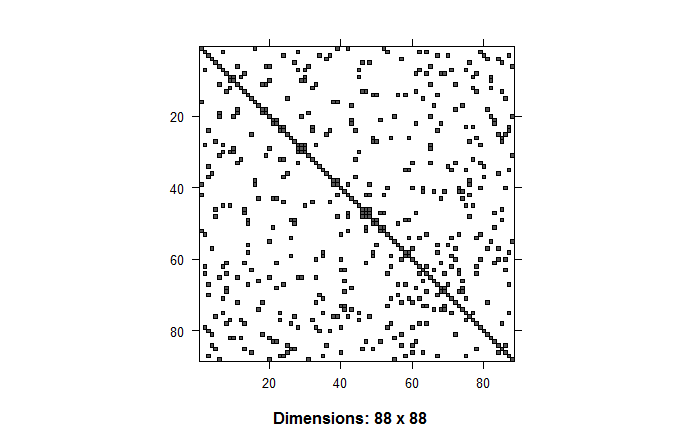

```r
temp <- poly2nb(ohio)
nb2INLA("z.graph", temp)
H <- inla.read.graph(filename="z.graph")
T <- inla.graph2matrix(H)
image(T,xlab="",ylab="")
```

```r
Ohio.adj <- paste(getwd(),"/z.graph",sep="")
```

Note that there already exists a .graph object within the downloaded dataset, “Ohio.graph”. Upon comparing, notice that our z.graph object is exactly identical to the Ohio.graph one provided. Thus, although this procedure was not necessary for our case, it might come in handy later on when a .graph file is not provided.

#### Running the BYM Model

This procedure is fairly simple:

```r
county1 <- data$county
formula.par <- y ~ 1 + f(county,model="bym",graph=Ohio.adj, constr=TRUE) + f(county1,year,model="iid", constr=TRUE) + year
model.par <- inla(formula.par,family="poisson",data=data,E=E,
                  control.predictor=list(compute=TRUE),
                  control.compute=list(dic=TRUE,cpo=TRUE))
round(model.par$summary.fixed[,1:5],3)
```

|  | mean | sd | 0.025quant | 0.5quant | 0.975quant |
| --- | --- | --- | --- | --- | --- |
| (Intercept) | -0.121 | 0.024 | -0.169 | -0.121 | -0.073 |
| year | 0.001 | 0.001 | 0.000 | 0.001 | 0.003 |

#### Plotting Figure 7.1

```r
x <- seq(1,21) # Years
plot(x,model.par$summary.fixed[2,1]*x, type="l", main="",xlab="t",ylab=expression(beta*t), ylim=c(-0.007,0.1))
lines(model.par$summary.fixed[2,3]*x,lty=2)
lines(model.par$summary.fixed[2,5]*x,lty=2)
```

[output not shown]

#### Plotting Figure 7.2 (left)

```r
m <- model.par$marginals.random[[1]][1:88]
zeta.ST1 <- unlist(lapply(m,function(x)inla.emarginal(exp,x)))

SMR.cutoff<- c(0.0, 0.9, 1.0, 1.1,3)
xi.factor <- cut(zeta.ST1,breaks=SMR.cutoff,include.lowest=TRUE)
m <- model.par$summary.random[[2]][1:88,2]
int.cut <- c(-0.008,-0.001,0,0.001,0.006)
int.factor <- cut(m,breaks=int.cut,include.lowest=TRUE)

data.ohio <- attr(ohio, "data")
attr(ohio, "data")=data.frame(data.ohio, xi=xi.factor)

trellis.par.set(axis.line=list(col=NA))
spplot(obj=ohio, zcol= "xi", col.regions=gray(3.5:0.5/4),main="")
```

[output not shown]

#### Plotting Figure 7.2 (right)

```r
data.ohio <- attr(ohio, "data")
attr(ohio, "data") <- data.frame(data.ohio, int=int.factor)
spplot(obj=ohio, zcol= "int",col.regions=gray(3.5:0.5/4),main="")
```

[output not shown]